# PEC3

Jose Romero de Gaetano

2025-05-04

- Sección 1: Regresión Lineal
  - Ejercicio 1
    - Apartado a)
    - Apartado b)
    - Apartado c)
    - Apartado d)
    - Apartado e)
  - Ejercicio 2
- Sección 2: ANOVA
  - Ejercicio 3
    - Apartado a)
    - Apartado b)
    - Apartado c)
    - Apartado d)
  - Ejercicio 4
    - Apartado 1)
    - Apartado 2)
    - Apartado 3)
    - Apartado 4
- Sección 3: Aplicaciones de R
  - Ejercicio 5
- Referencias
- Anexo

# Sección 1: Regresión Lineal

## Ejercicio 1

**A partir del conjunto de datos Pima.tr (del paquete MASS) sobre mujeres indígenas Pima y su riesgo de diabetes, se destacan las siguientes variables:**

**Variables relevantes:**

- glu: concentración de glucosa en sangre

- age: edad de la persona

- bmi: índice de masa corporal (BMI)

- diabetes: diagnóstico de diabetes (Sí/No)

Información del Dataset: https://rdrr.io/cran/MASS/man/Pima.tr.html

**a) Carga y explora el conjunto de datos.**

**b) Realiza un gráfico de dispersión entre el índice de masa corporal bmi) y la concentración de glucosa (glu).**

**c) Ajusta un modelo de regresión lineal con glu como variable dependiente y bmi como variable independiente.**

**d) Interpreta el coeficiente de regresión y el valor de R² del modelo.**

**e) Analiza los residuos del modelo para validar los supuestos de regresión.**

### Apartado a)

```r
# a) Cargamos y exploramos el conjunto de datos 'Pima.tr'
# Cargamos libreria 'MASS'
library(MASS)
data("Pima.tr")

# Visualizamos las primeras filas
head(Pima.tr)
```

|  | npreg | glu | bp | skin | bmi | ped | age | type |
| --- | --- | --- | --- | --- | --- | --- | --- | --- |
| 1 | 5 | 86 | 68 | 28 | 30.2 | 0.364 | 24 | No |
| 2 | 7 | 195 | 70 | 33 | 25.1 | 0.163 | 55 | Yes |
| 3 | 5 | 77 | 82 | 41 | 35.8 | 0.156 | 35 | No |
| 4 | 0 | 165 | 76 | 43 | 47.9 | 0.259 | 26 | No |
| 5 | 0 | 107 | 60 | 25 | 26.4 | 0.133 | 23 | No |
| 6 | 5 | 97 | 76 | 27 | 35.6 | 0.378 | 52 | Yes |

```r
# Estructura de los datos
str(Pima.tr)
```

```
## 'data.frame':    200 obs. of  8 variables:
##  $ npreg: int  5 7 5 0 0 5 3 1 3 2 ...
##  $ glu  : int  86 195 77 165 107 97 83 193 142 128 ...
##  $ bp   : int  68 70 82 76 60 76 58 50 80 78 ...
##  $ skin : int  28 33 41 43 25 27 31 16 15 37 ...
##  $ bmi  : num  30.2 25.1 35.8 47.9 26.4 35.6 34.3 25.9 32.4 43.3 ...
##  $ ped  : num  0.364 0.163 0.156 0.259 0.133 ...
##  $ age  : int  24 55 35 26 23 52 25 24 63 31 ...
##  $ type : Factor w/ 2 levels "No","Yes": 1 2 1 1 1 2 1 1 1 2 ...
```

```r
# Nombre de las variables
names(Pima.tr)
```

```
## [1] "npreg" "glu"   "bp"    "skin"  "bmi"   "ped"   "age"   "type"
```

El conjunto de datos ‘Pima.tr’ de la libreria ‘MASS’ forma parte de un estudio que fue realizado por el *National Institute of Diabetes and Digestive and Kidney Diseases*, contiene observaciones de mujeres de la etnia *Pima* (índigena americano), con el objetivo de predecir la presencia de diabetes a partir de distintas variables médicas y personales. Encotramos las siguientes variables:

- **npreg** (*variable numérica tipo int*): estudia el número de embarazos previos.
- **glu** (*variable numérica tipo int*): concentración de glucosa en sangre en mg/dL.
- **bp** (*variable numérica tipo int*): estudia la presión sanguínea en mmHg.
- **skin** (*variable numérica tipo int*): relacionado con la grasa corporal, estudia el grosor del pliegue cutáneo tricipital en mm.
- **bmi** (*variable numérica tipo float*): Índice de Masa Corporal (IMC) en kg/m^2.
- **ped** (*variable numérica tipo float*): estudia la probabilidad de tener diabetes (en base al pedigrí según antecedentes familiares).
- **age** (*variable numérica tipo int*): edad en años.
- **type** (*factor*): es la variable objetivo, “No diabetes” (1) o “Sí diabetes” (2).

```r
# Revisamos si hay algún valor NA
sum(is.na(Pima.tr)) # no hay valores NA
```

```
## [1] 0
```

```r
# Resumen estadístico
summary(Pima.tr)
```

```
##      npreg            glu              bp              skin            bmi             ped              age
##  Min.   : 0.00   Min.   : 56.0   Min.   : 38.00   Min.   : 7.00   Min.   :18.20   Min.   :0.0850   Min.   :21.00
##  1st Qu.: 1.00   1st Qu.:100.0   1st Qu.: 64.00   1st Qu.:20.75   1st Qu.:27.57   1st Qu.:0.2535   1st Qu.:23.00
##  Median : 2.00   Median :120.5   Median : 70.00   Median :29.00   Median :32.80   Median :0.3725   Median :28.00
##  Mean   : 3.57   Mean   :124.0   Mean   : 71.26   Mean   :29.21   Mean   :32.31   Mean   :0.4608   Mean   :32.11
##  3rd Qu.: 6.00   3rd Qu.:144.0   3rd Qu.: 78.00   3rd Qu.:36.00   3rd Qu.:36.50   3rd Qu.:0.6160   3rd Qu.:39.25
##  Max.   :14.00   Max.   :199.0   Max.   :110.00   Max.   :99.00   Max.   :47.90   Max.   :2.2880   Max.   :63.00
##   type
##  No :132
##  Yes: 68
##
##
##
##
```

### Apartado b)

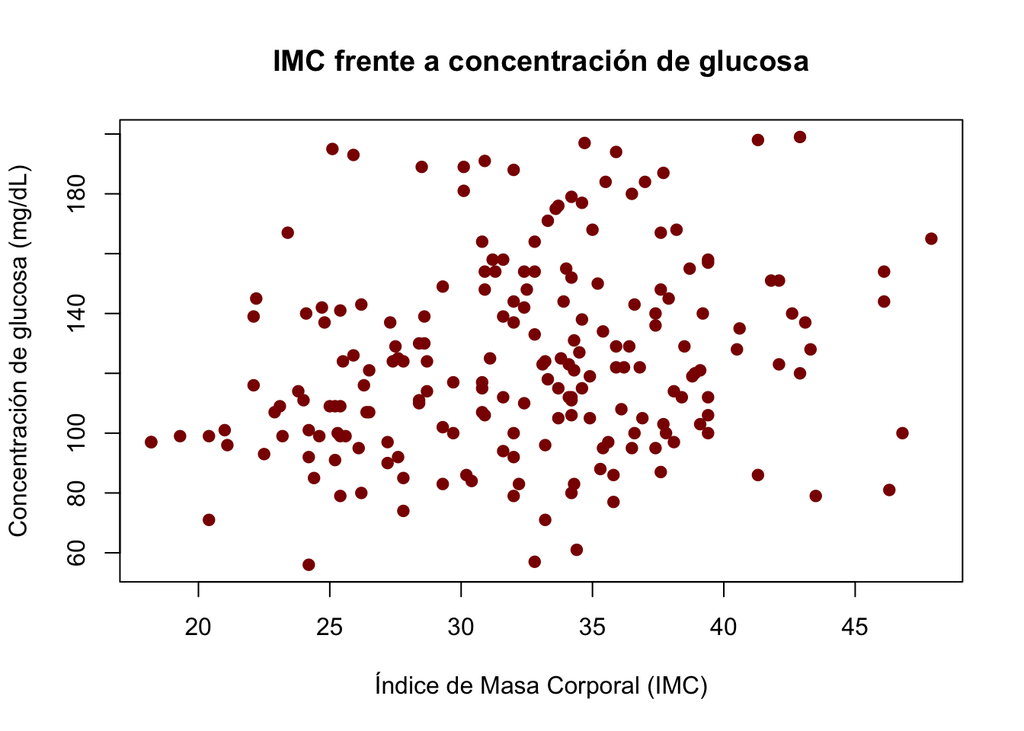

```r
# b) Realiza un gráfico de dispersión entre el índice de masa corporal bmi)
# y la concentración de glucosa (glu).
plot(Pima.tr$bmi, Pima.tr$glu,
     xlab = "Índice de Masa Corporal (IMC)",
     ylab = "Concentración de glucosa (mg/dL)",
     main = "IMC frente a concentración de glucosa",
       pch = 19, col = "darkred")
```

En el gráfico observamos el IMC frente a la concentración de glucosa, para estudiar si hay algún tipo de correlación entre el IMC y [glucosa] podemos proceder con un análisis estadístico.

### Apartado c)

```r
# c) Ajusta un modelo de regresión lineal con glu como variable dependiente y bmi como
# variable independiente.

# Podemos estudiar la relación entre las variables IMC y [glu]
# calculando el coeficiente de correlación
cor(Pima.tr[,c("glu", "bmi")], use = "complete")
```

```
##           glu       bmi
## glu 1.0000000 0.2167899
## bmi 0.2167899 1.0000000
```

A partir del coeficiente de correlación se observa una ligera tendencia positiva, lo que significa que a medida que el IMC aumenta podría suponer un aumento de la concentración de glucosa, no obstante, el valor es cercano a 0 (no muy elevado) lo que significa que solo el valor IMC no sería suficiente para explicar el aumento de la concentración de glucosa, pues podrían verse implicada las otras variables también en su determinación.

Para proseguir con el estudio de ambas variables procedemos con el modelo de regresión lineal.

```r
# Modelo de regresión lineal
regmodel <- lm(glu~bmi, data = Pima.tr)
summary(regmodel)
```

```
##
## Call:
## lm(formula = glu ~ bmi, data = Pima.tr)
##
## Residuals:
##     Min      1Q  Median      3Q     Max
## -67.519 -20.292  -5.239  19.483  79.104
##
## Coefficients:
##             Estimate Std. Error t value Pr(>|t|)
## (Intercept)  87.7865    11.7849   7.449 2.84e-12 ***
## bmi           1.1199     0.3584   3.125  0.00205 **
## ---
## Signif. codes:  0 '***' 0.001 '**' 0.01 '*' 0.05 '.' 0.1 ' ' 1
##
## Residual standard error: 30.99 on 198 degrees of freedom
## Multiple R-squared:  0.047,  Adjusted R-squared:  0.04218
## F-statistic: 9.764 on 1 and 198 DF,  p-value: 0.002046
```

```r
# Coeficiente de regresión
lm(formula = glu ~ bmi, data = Pima.tr)
```

```
##
## Call:
## lm(formula = glu ~ bmi, data = Pima.tr)
##
## Coefficients:
## (Intercept)          bmi
##       87.79         1.12
```

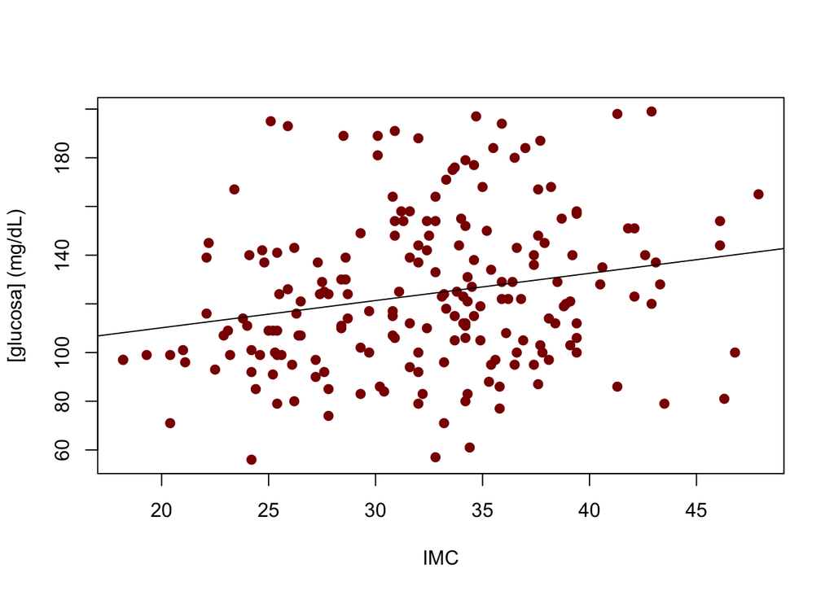

```r
# Grafico con la linea de regresion
plot(Pima.tr$bmi, Pima.tr$glu, xlab = "IMC", ylab = "[glucosa] (mg/dL)",
      pch = 19, col = "darkred")
abline(regmodel)
```

### Apartado d)

**d) Interpreta el coeficiente de regresión y el valor de R² del modelo.**

- Ecuación de la recta: glu = 87.79 + 1.12 * bmi
- t valor (bmi): 3.125
- p valor (bmi): 0.00205
- R^2: 0.047

De los valores del coeficiente de regresión deducimos que a medida que los valores del IMC aumenta también lo hacen los valores de [glucosa] con una pendiente no muy elevada.

### Apartado e)

**e) Analiza los residuos del modelo para validar los supuestos de regresión.**

Encontramos los siguientes valores para los residuos:

- Mínimo: -67.519
- 1er Cuartil: -20.292
- Mediana: -5.239
- 3er Cuartil_ 19.483
- Máximo: 79.104

Los residuos representan la diferencia entre y los valores que predicen el modelo lineal a partir del IMC. Aunque la mayoría de valores se encuentran correctamente distribuidos, observamos que algunos valores como el mínimo (-67.519) y el máximo (+79.104) son muy extremos, lo que puede significar que el modelo no predice correctamente para todos los casos, esto como hemos visto anteriormente también viene refleado por el bajo valor de R^2 (0.047). Hay relación entre ambas variables pero dicha relación es ligera.

## Ejercicio 2

**Busca un paquete de R o genera unos datos inventados que tengan un coeficiente de Regresión alto y aplica los pasos que se explican en la solución del Caso práctico 2 del LAB 6.**

Recordamos el caso práctico 2 del LAB5:

[…]*Se pide realizar un estudio de regresión lineal, regresión múltiple, test ANOVA y test clustering sobre dicho conjunto de datos. Las variables elegidas en cada uno de los casos posibles que tratar se dan a elegir al estudiante.*

Realizamos el ejercicio a partir del conjunto de datos ‘mtcars’ contiene información sobre el consumo de combustible. y distintas características en distintos automóviles.

```r
# Cargamos los datos
data("mtcars")

# Visualizamos las primeras filas de mtcars
head(mtcars)
```

|  | mpg | cyl | disp | hp | drat | wt | qsec | vs | am | gear | carb |
| --- | --- | --- | --- | --- | --- | --- | --- | --- | --- | --- | --- |
| Mazda RX4 | 21.0 | 6 | 160 | 110 | 3.90 | 2.620 | 16.46 | 0 | 1 | 4 | 4 |
| Mazda RX4 Wag | 21.0 | 6 | 160 | 110 | 3.90 | 2.875 | 17.02 | 0 | 1 | 4 | 4 |
| Datsun 710 | 22.8 | 4 | 108 | 93 | 3.85 | 2.320 | 18.61 | 1 | 1 | 4 | 1 |
| Hornet 4 Drive | 21.4 | 6 | 258 | 110 | 3.08 | 3.215 | 19.44 | 1 | 0 | 3 | 1 |
| Hornet Sportabout | 18.7 | 8 | 360 | 175 | 3.15 | 3.440 | 17.02 | 0 | 0 | 3 | 2 |
| Valiant | 18.1 | 6 | 225 | 105 | 2.76 | 3.460 | 20.22 | 1 | 0 | 3 | 1 |

```r
# Descripcion de las variables
str(mtcars)
```

```
## 'data.frame':    32 obs. of  11 variables:
##  $ mpg : num  21 21 22.8 21.4 18.7 18.1 14.3 24.4 22.8 19.2 ...
##  $ cyl : num  6 6 4 6 8 6 8 4 4 6 ...
##  $ disp: num  160 160 108 258 360 ...
##  $ hp  : num  110 110 93 110 175 105 245 62 95 123 ...
##  $ drat: num  3.9 3.9 3.85 3.08 3.15 2.76 3.21 3.69 3.92 3.92 ...
##  $ wt  : num  2.62 2.88 2.32 3.21 3.44 ...
##  $ qsec: num  16.5 17 18.6 19.4 17 ...
##  $ vs  : num  0 0 1 1 0 1 0 1 1 1 ...
##  $ am  : num  1 1 1 0 0 0 0 0 0 0 ...
##  $ gear: num  4 4 4 3 3 3 3 4 4 4 ...
##  $ carb: num  4 4 1 1 2 1 4 2 2 4 ...
```

```r
# Revisamos si hay valores NA
sum(is.na(mtcars))
```

```
## [1] 0
```

Encontramos las siguientes variables:

- mpg: eficiencia del combustible (medida en millas/galón).
- cyl: número de cilindros del motor.
- disp: cilindros del motor en pulgadas cúbicas.
- hp: potencia bruta del motor.
- drat: relación del eje trasero.
- wt: peso del vehículo en milipounds (miles de libras).
- qsec: tiempo en seg. para recorrer un cuarto de milla
- vs: tipo de motor, 0: en V y 1: en línea.
- am: tipo de transmisión, 0: automático y 1: manual.
- gear: número de marchas hacia delante.
- carb: número de carburadores.

```r
# Resumen estadístico
summary(mtcars)
```

```
##       mpg             cyl             disp             hp             drat             wt             qsec
##  Min.   :10.40   Min.   :4.000   Min.   : 71.1   Min.   : 52.0   Min.   :2.760   Min.   :1.513   Min.   :14.50
##  1st Qu.:15.43   1st Qu.:4.000   1st Qu.:120.8   1st Qu.: 96.5   1st Qu.:3.080   1st Qu.:2.581   1st Qu.:16.89
##  Median :19.20   Median :6.000   Median :196.3   Median :123.0   Median :3.695   Median :3.325   Median :17.71
##  Mean   :20.09   Mean   :6.188   Mean   :230.7   Mean   :146.7   Mean   :3.597   Mean   :3.217   Mean   :17.85
##  3rd Qu.:22.80   3rd Qu.:8.000   3rd Qu.:326.0   3rd Qu.:180.0   3rd Qu.:3.920   3rd Qu.:3.610   3rd Qu.:18.90
##  Max.   :33.90   Max.   :8.000   Max.   :472.0   Max.   :335.0   Max.   :4.930   Max.   :5.424   Max.   :22.90
##        vs               am              gear            carb
##  Min.   :0.0000   Min.   :0.0000   Min.   :3.000   Min.   :1.000
##  1st Qu.:0.0000   1st Qu.:0.0000   1st Qu.:3.000   1st Qu.:2.000
##  Median :0.0000   Median :0.0000   Median :4.000   Median :2.000
##  Mean   :0.4375   Mean   :0.4062   Mean   :3.688   Mean   :2.812
##  3rd Qu.:1.0000   3rd Qu.:1.0000   3rd Qu.:4.000   3rd Qu.:4.000
##  Max.   :1.0000   Max.   :1.0000   Max.   :5.000   Max.   :8.000
```

```r
# Para estudiar la relación entre variables,
# calculamos la matriz de correlaciones
cor(x = mtcars, method = "pearson")
```

```
##             mpg        cyl       disp         hp        drat         wt        qsec         vs          am
## mpg   1.0000000 -0.8521620 -0.8475514 -0.7761684  0.68117191 -0.8676594  0.41868403  0.6640389  0.59983243
## cyl  -0.8521620  1.0000000  0.9020329  0.8324475 -0.69993811  0.7824958 -0.59124207 -0.8108118 -0.52260705
## disp -0.8475514  0.9020329  1.0000000  0.7909486 -0.71021393  0.8879799 -0.43369788 -0.7104159 -0.59122704
## hp   -0.7761684  0.8324475  0.7909486  1.0000000 -0.44875912  0.6587479 -0.70822339 -0.7230967 -0.24320426
## drat  0.6811719 -0.6999381 -0.7102139 -0.4487591  1.00000000 -0.7124406  0.09120476  0.4402785  0.71271113
## wt   -0.8676594  0.7824958  0.8879799  0.6587479 -0.71244065  1.0000000 -0.17471588 -0.5549157 -0.69249526
## qsec  0.4186840 -0.5912421 -0.4336979 -0.7082234  0.09120476 -0.1747159  1.00000000  0.7445354 -0.22986086
## vs    0.6640389 -0.8108118 -0.7104159 -0.7230967  0.44027846 -0.5549157  0.74453544  1.0000000  0.16834512
## am    0.5998324 -0.5226070 -0.5912270 -0.2432043  0.71271113 -0.6924953 -0.22986086  0.1683451  1.00000000
## gear  0.4802848 -0.4926866 -0.5555692 -0.1257043  0.69961013 -0.5832870 -0.21268223  0.2060233  0.79405876
## carb -0.5509251  0.5269883  0.3949769  0.7498125 -0.09078980  0.4276059 -0.65624923 -0.5696071  0.05753435
##            gear        carb
## mpg   0.4802848 -0.55092507
## cyl  -0.4926866  0.52698829
## disp -0.5555692  0.39497686
## hp   -0.1257043  0.74981247
## drat  0.6996101 -0.09078980
## wt   -0.5832870  0.42760594
## qsec -0.2126822 -0.65624923
## vs    0.2060233 -0.56960714
## am    0.7940588  0.05753435
## gear  1.0000000  0.27407284
## carb  0.2740728  1.00000000
```

Observamos alta correlacion entre:

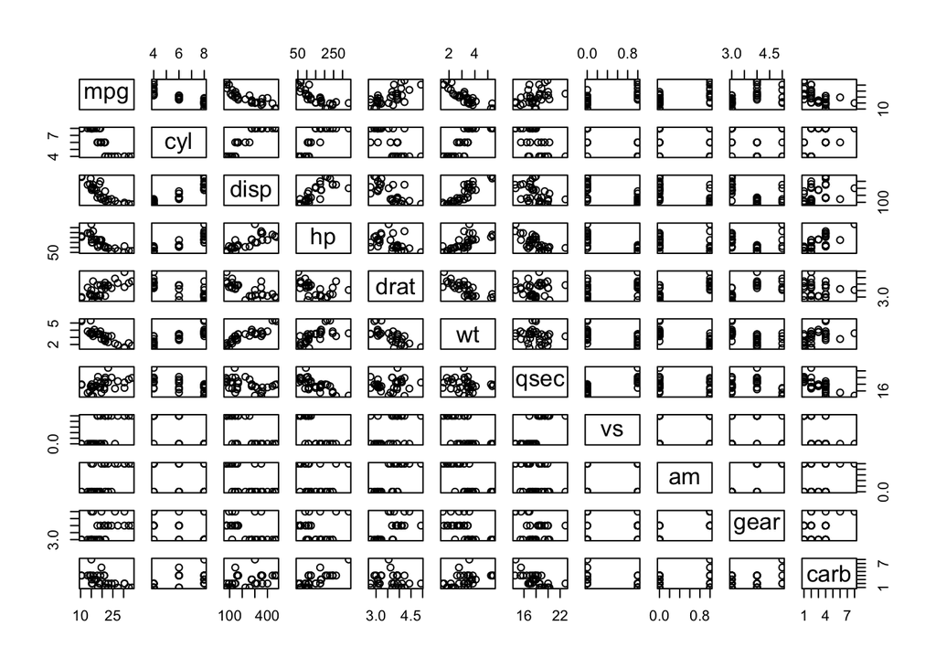

```r
# Representamos la relación entre variables
pairs(mtcars)
```

```r
# Realizamos el modelo de regresion lineal,
# entre el peso del coche 'mpg' y el consumo 'wt'
mod_reg_car <- lm(formula = mpg ~ wt, data = mtcars)
# mostramos el resultado
summary(mod_reg_car)
```

```
##
## Call:
## lm(formula = mpg ~ wt, data = mtcars)
##
## Residuals:
##     Min      1Q  Median      3Q     Max
## -4.5432 -2.3647 -0.1252  1.4096  6.8727
##
## Coefficients:
##             Estimate Std. Error t value Pr(>|t|)
## (Intercept)  37.2851     1.8776  19.858  < 2e-16 ***
## wt           -5.3445     0.5591  -9.559 1.29e-10 ***
## ---
## Signif. codes:  0 '***' 0.001 '**' 0.01 '*' 0.05 '.' 0.1 ' ' 1
##
## Residual standard error: 3.046 on 30 degrees of freedom
## Multiple R-squared:  0.7528, Adjusted R-squared:  0.7446
## F-statistic: 91.38 on 1 and 30 DF,  p-value: 1.294e-10
```

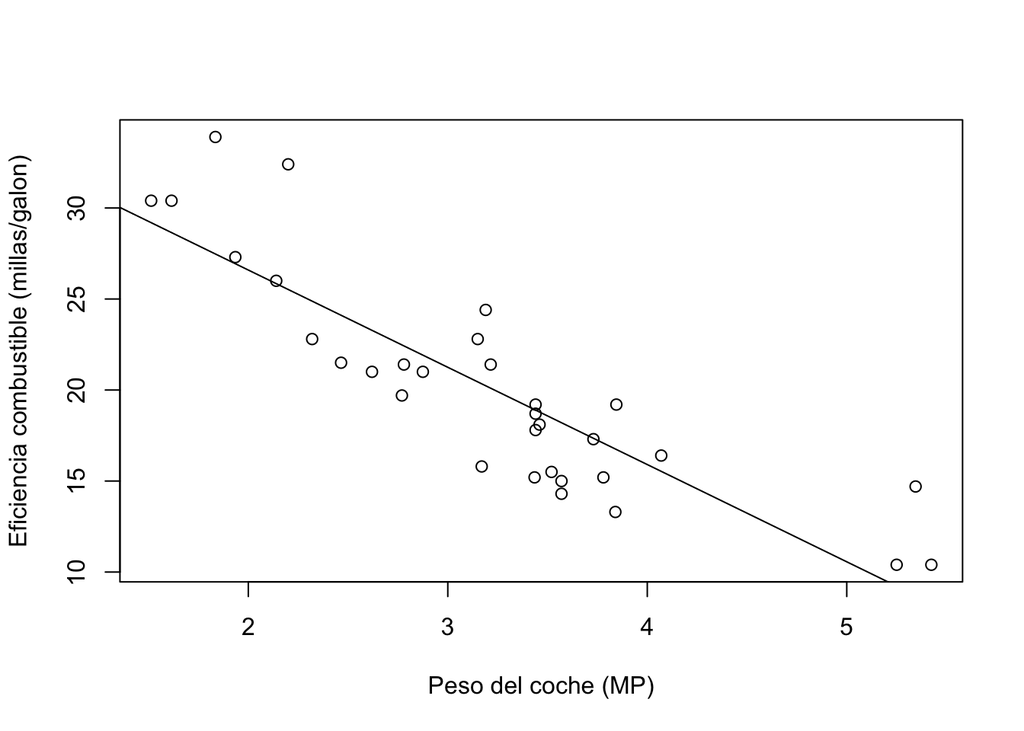

```r
# Representamos el gráfico
plot(mtcars$mpg ~ mtcars$wt,
    xlab = "Peso del coche (MP)",
    ylab = "Eficiencia combustible (millas/galon)")
abline(mod_reg_car)
```

Regresión lineal simple: y = 37.2851 − 5.3445 * x

- R^2 = 0.7528 (buen ajuste del modelo)
- p valor: 1.29e-10 (< 0.05)
- F statistic: 91.38 (modelo estadísticamente significativo)

Dado el valor de R^2 (cercano a 1) y el p valor (< 0.05), deducimos que el peso tiene una influencia en la eficiencia o rendimiento del coche.

Se observa una relación negativa por lo que a mayor peso del coche (‘wt’) menor eficiencia del combustible (‘mpg’).

```r
# Modelo de regresión múltiple
coches_rm <- lm(mtcars$mpg~mtcars$cyl+mtcars$disp+mtcars$hp+mtcars$drat+mtcars$wt+mtcars$qsec+
                  mtcars$vs+mtcars$am+mtcars$gear+mtcars$carb, data = mtcars)

# Resultados
summary(coches_rm)
```

```
##
## Call:
## lm(formula = mtcars$mpg ~ mtcars$cyl + mtcars$disp + mtcars$hp +
##     mtcars$drat + mtcars$wt + mtcars$qsec + mtcars$vs + mtcars$am +
##     mtcars$gear + mtcars$carb, data = mtcars)
##
## Residuals:
##     Min      1Q  Median      3Q     Max
## -3.4506 -1.6044 -0.1196  1.2193  4.6271
##
## Coefficients:
##             Estimate Std. Error t value Pr(>|t|)
## (Intercept) 12.30337   18.71788   0.657   0.5181
## mtcars$cyl  -0.11144    1.04502  -0.107   0.9161
## mtcars$disp  0.01334    0.01786   0.747   0.4635
## mtcars$hp   -0.02148    0.02177  -0.987   0.3350
## mtcars$drat  0.78711    1.63537   0.481   0.6353
## mtcars$wt   -3.71530    1.89441  -1.961   0.0633 .
## mtcars$qsec  0.82104    0.73084   1.123   0.2739
## mtcars$vs    0.31776    2.10451   0.151   0.8814
## mtcars$am    2.52023    2.05665   1.225   0.2340
## mtcars$gear  0.65541    1.49326   0.439   0.6652
## mtcars$carb -0.19942    0.82875  -0.241   0.8122
## ---
## Signif. codes:  0 '***' 0.001 '**' 0.01 '*' 0.05 '.' 0.1 ' ' 1
##
## Residual standard error: 2.65 on 21 degrees of freedom
## Multiple R-squared:  0.869,  Adjusted R-squared:  0.8066
## F-statistic: 13.93 on 10 and 21 DF,  p-value: 3.793e-07
```

```r
# Evaluamos cuales son los mejores predictores
step(object = coches_rm, direction = "both", trace = 1)
```

```
## Start:  AIC=70.9
## mtcars$mpg ~ mtcars$cyl + mtcars$disp + mtcars$hp + mtcars$drat +
##     mtcars$wt + mtcars$qsec + mtcars$vs + mtcars$am + mtcars$gear +
##     mtcars$carb
##
##               Df Sum of Sq    RSS    AIC
## - mtcars$cyl   1    0.0799 147.57 68.915
## - mtcars$vs    1    0.1601 147.66 68.932
## - mtcars$carb  1    0.4067 147.90 68.986
## - mtcars$gear  1    1.3531 148.85 69.190
## - mtcars$drat  1    1.6270 149.12 69.249
## - mtcars$disp  1    3.9167 151.41 69.736
## - mtcars$hp    1    6.8399 154.33 70.348
## - mtcars$qsec  1    8.8641 156.36 70.765
## <none>                     147.49 70.898
## - mtcars$am    1   10.5467 158.04 71.108
## - mtcars$wt    1   27.0144 174.51 74.280
##
## Step:  AIC=68.92
## mtcars$mpg ~ mtcars$disp + mtcars$hp + mtcars$drat + mtcars$wt +
##     mtcars$qsec + mtcars$vs + mtcars$am + mtcars$gear + mtcars$carb
##
##               Df Sum of Sq    RSS    AIC
## - mtcars$vs    1    0.2685 147.84 66.973
## - mtcars$carb  1    0.5201 148.09 67.028
## - mtcars$gear  1    1.8211 149.40 67.308
## - mtcars$drat  1    1.9826 149.56 67.342
## - mtcars$disp  1    3.9009 151.47 67.750
## - mtcars$hp    1    7.3632 154.94 68.473
## <none>                     147.57 68.915
## - mtcars$qsec  1   10.0933 157.67 69.032
## - mtcars$am    1   11.8359 159.41 69.384
## + mtcars$cyl   1    0.0799 147.49 70.898
## - mtcars$wt    1   27.0280 174.60 72.297
##
## Step:  AIC=66.97
## mtcars$mpg ~ mtcars$disp + mtcars$hp + mtcars$drat + mtcars$wt +
##     mtcars$qsec + mtcars$am + mtcars$gear + mtcars$carb
##
##               Df Sum of Sq    RSS    AIC
```

[output cut: 79 more lines]

```
## Step:  AIC=61.31
## mtcars$mpg ~ mtcars$wt + mtcars$qsec + mtcars$am
##
##               Df Sum of Sq    RSS    AIC
## <none>                     169.29 61.307
## + mtcars$hp    1     9.219 160.07 61.515
## + mtcars$carb  1     8.036 161.25 61.751
## + mtcars$disp  1     3.276 166.01 62.682
## + mtcars$cyl   1     1.501 167.78 63.022
## + mtcars$drat  1     1.400 167.89 63.042
## + mtcars$gear  1     0.123 169.16 63.284
## + mtcars$vs    1     0.000 169.29 63.307
## - mtcars$am    1    26.178 195.46 63.908
## - mtcars$qsec  1   109.034 278.32 75.217
## - mtcars$wt    1   183.347 352.63 82.790
```

```
##
## Call:
## lm(formula = mtcars$mpg ~ mtcars$wt + mtcars$qsec + mtcars$am,
##     data = mtcars)
##
## Coefficients:
## (Intercept)    mtcars$wt  mtcars$qsec    mtcars$am
##       9.618       -3.917        1.226        2.936
```

Observamos que los mejores predictores son ‘wt’, ‘qsec’ y ‘am’.

Calculamos de nuevo el modelo de regresión con estos predictores

```r
# Modelo de regresión múltiple con los mejores predictoes
coches_rm_p <- lm(mtcars$mpg~mtcars$wt+mtcars$qsec+mtcars$am, data = mtcars)
summary(coches_rm_p)
```

```
##
## Call:
## lm(formula = mtcars$mpg ~ mtcars$wt + mtcars$qsec + mtcars$am,
##     data = mtcars)
##
## Residuals:
##     Min      1Q  Median      3Q     Max
## -3.4811 -1.5555 -0.7257  1.4110  4.6610
##
## Coefficients:
##             Estimate Std. Error t value Pr(>|t|)
## (Intercept)   9.6178     6.9596   1.382 0.177915
## mtcars$wt    -3.9165     0.7112  -5.507 6.95e-06 ***
## mtcars$qsec   1.2259     0.2887   4.247 0.000216 ***
## mtcars$am     2.9358     1.4109   2.081 0.046716 *
## ---
## Signif. codes:  0 '***' 0.001 '**' 0.01 '*' 0.05 '.' 0.1 ' ' 1
##
## Residual standard error: 2.459 on 28 degrees of freedom
## Multiple R-squared:  0.8497, Adjusted R-squared:  0.8336
## F-statistic: 52.75 on 3 and 28 DF,  p-value: 1.21e-11
```

Observamos los siguientes valores:

- R^2: 0.8497
- F statistic: 52.75
- p valor: 1.21e-11

El valor de R^2 sugiere que el modelo tiene un buen ajuste entre las variables que influyen en ‘mpg’ (eficiencia del coche). Además, el F statistic tiene un valor de 52.7 5con un p-valor muy bajo (< 0.001), lo que indica que el modelo es estadísticamente significativo.

```r
# AOV entre 'mpg' y 'wt'
modelo_aov <- aov(mpg~factor(cyl), data = mtcars)
summary(modelo_aov)
```

```
##             Df Sum Sq Mean Sq F value   Pr(>F)
## factor(cyl)  2  824.8   412.4    39.7 4.98e-09 ***
## Residuals   29  301.3    10.4
## ---
## Signif. codes:  0 '***' 0.001 '**' 0.01 '*' 0.05 '.' 0.1 ' ' 1
```

Observamos que el F valor de 39.7 es elevado y el p valor 4.98e-09 es < 0.05, por lo que el número de cilindros (‘cyl’) influye en la eficiencia del coche (‘mpg’).

Procedemos ahora con un agrupamiento jerárquico agloemrativo en el que cada observación es un clúster que se va organizando hasta converger en una única rama central.

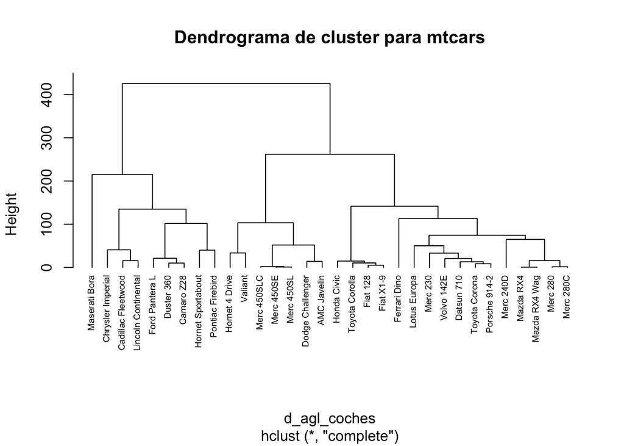

```r
# Agrupamiento jerárquico aglomerativo
library(cluster) # cargamos libreria

# Especificamos los valores de distancia
d_agl_coches <- dist(mtcars, method = "euclidean")
# Calculamos el cluster
hc_agl_coches <- hclust(d_agl_coches, method = "complete")
# Representamos el dendrograma
plot(hc_agl_coches, cex = 0.6, hang = -1, main = "Dendrograma de cluster para mtcars")
```

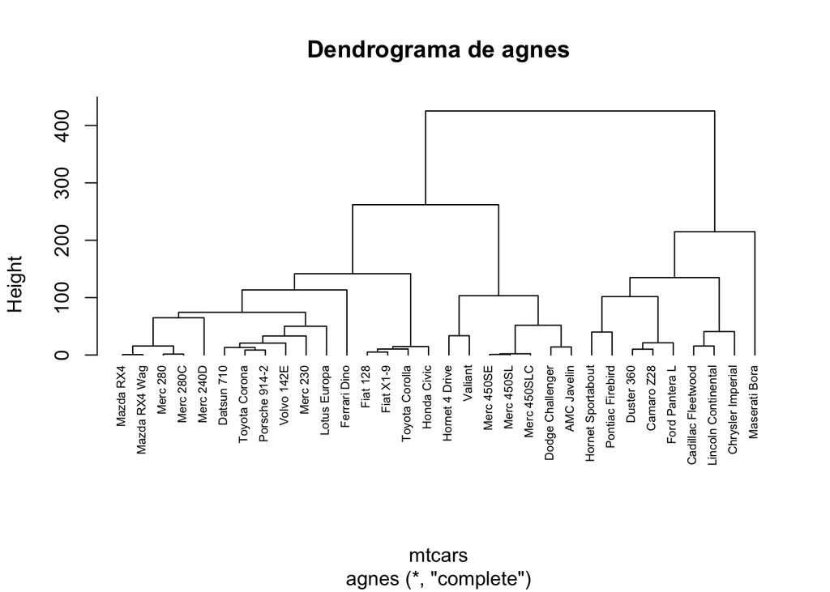

```r
# Agrupamiento jerárquico usando la función de agnes
# Cálculamos los clústeres
hc_agl_coches_a <- agnes(mtcars, method = "complete")
# Representación del dendrograma
pltree(hc_agl_coches_a, cex = 0.6, hang = -1, main = "Dendrograma de agnes")
```

```r
# Calculamos el coeficiente de aglomeración
hc_agl_coches_a$ac
```

```
## [1] 0.9368123
```

El coeficiente de aglomeración es 0.93 por lo que la agrupación es fuerte.

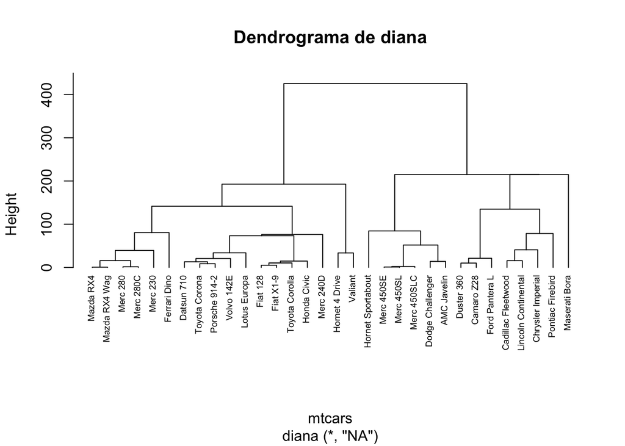

```r
# Agrupamiento jerárquico divisivo con la función diana
hc_div_coches <- diana(mtcars) # calculamos los clústeres
pltree(hc_div_coches, cex = 0.6, hang = -1, main = "Dendrograma de diana") # lo representamos
```

```r
hc_div_coches$dc # coeficiente de división
```

```
## [1] 0.9330235
```

El coeficiente de divisón es 0.93 también (muy próximo a 1).

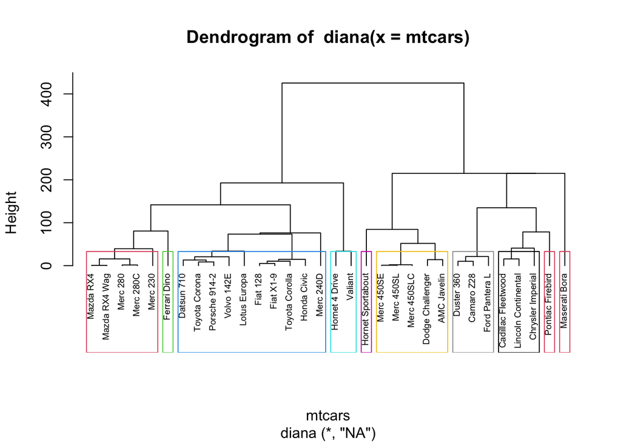

```r
# Asociamos los agrupamientos a los datos
pltree(hc_div_coches, cex = 0.6, hang = -1) # representación
rect.hclust(hc_div_coches, k = 10, border = 2:10) # asociaciones
```

# Sección 2: ANOVA

## Ejercicio 3

**A partir del conjunto de datos: PlantGrowth (incluido en R en la librería Plotly).**

Variables:

weight: peso de las plantas

group: tratamiento aplicado (control o dos tipos de suplemento)

**Tareas a realizar:**

**a) Haz un box plot para comparar el peso según el tratamiento.**

**b) Ajusta un modelo ANOVA para ver si existen diferencias significativas entre grupos.**

**c) Interpreta los resultados y comprueba si es necesario añadir interacciones.**

**d) Válida el modelo con el análisis de los residuos.**

### Apartado a)

El conjunto de datos ‘PlantGrowth’ estudia el crecimiento de las plantas en respuesta a distintos tratamientos.

```r
# a) Haz un box plot para comparar el peso según el tratamiento.

# Cargamos la liberia y los datos
library(plotly)
data("PlantGrowth")

# Primeras líneas
head(PlantGrowth)
```

|  | weight | group |
| --- | --- | --- |
| 1 | 4.17 | ctrl |
| 2 | 5.58 | ctrl |
| 3 | 5.18 | ctrl |
| 4 | 6.11 | ctrl |
| 5 | 4.50 | ctrl |
| 6 | 4.61 | ctrl |

```r
# Estructura de datos
str(PlantGrowth)
```

```
## 'data.frame':    30 obs. of  2 variables:
##  $ weight: num  4.17 5.58 5.18 6.11 4.5 4.61 5.17 4.53 5.33 5.14 ...
##  $ group : Factor w/ 3 levels "ctrl","trt1",..: 1 1 1 1 1 1 1 1 1 1 ...
```

```r
# Revisamos si hay valores NA
sum(is.na(PlantGrowth))
```

```
## [1] 0
```

```r
# Resumen estadístico
summary(PlantGrowth)
```

```
##      weight       group
##  Min.   :3.590   ctrl:10
##  1st Qu.:4.550   trt1:10
##  Median :5.155   trt2:10
##  Mean   :5.073
##  3rd Qu.:5.530
##  Max.   :6.310
```

Contamos con dos variables:

- weight: peso seco de la planta
- group: grupo de tratamiento, puede ser control ‘ctrl’, tratamiento 1 ‘trt1’ y tratamiento 2 ‘trt2’.

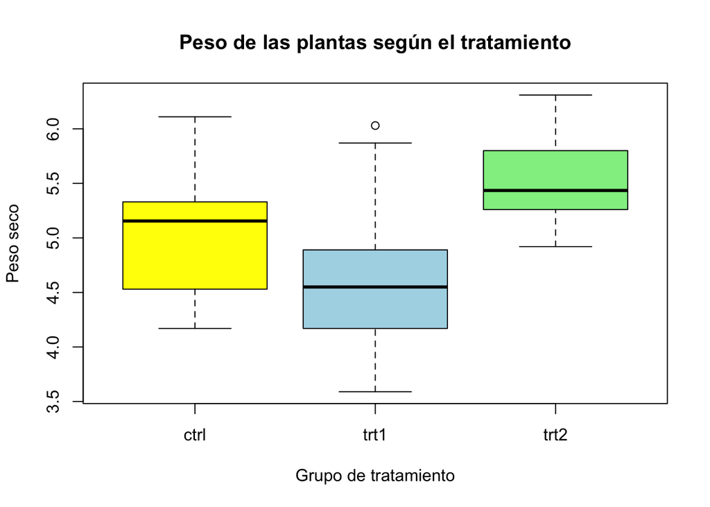

```r
# Creamos un boxplot para comparar el peso según el tratamiento
boxplot(weight ~ group,
        data = PlantGrowth,
        col = c("yellow", "lightblue", "lightgreen"),
        xlab = "Grupo de tratamiento",
        ylab = "Peso seco",
        main = "Peso de las plantas según el tratamiento")
```

De boxplot observamos que respecto del grupo control, las plantas del tratamiento 1 presentan menor peso y las plantas del grupo 2 mayor peso, por lo que podría haber una relación negativa entre el tratamiento 1 y el peso y una relación positiva entre el tratamiento 2 y el peso.

### Apartado b)

```r
# modelo ANOVA
aov_plantas <- aov(weight ~ group, data = PlantGrowth)
summary(aov_plantas)
```

```
##             Df Sum Sq Mean Sq F value Pr(>F)
## group        2  3.766  1.8832   4.846 0.0159 *
## Residuals   27 10.492  0.3886
## ---
## Signif. codes:  0 '***' 0.001 '**' 0.01 '*' 0.05 '.' 0.1 ' ' 1
```

### Apartado c)

Tras realizar el anova observamos que el p valor 0.0159 es < 0.05, lo que implica que si hay diferencia significativa y los tratamientos afectan al crecimiento de las plantas.

En el estudio no disponemos de mas variables que puedan influir en el peso de las plantes, además del tratamiento.

Sería interesante ampliar el estudio para considerar el posbile impacto de otras variables como condiciones a las que se someten las plantas, como: horas de luz, riego, nutrientes, etc… Para estudiar si hay mas variables que ejercen una influencia estadísticamente significativa en el peso de las plantas.

### Apartado d)

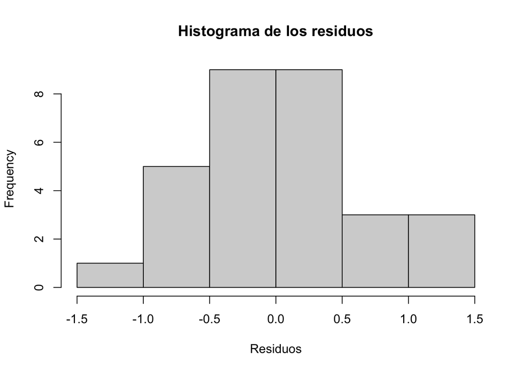

```r
# Extraemos los residuos
residuos <- residuals(aov_plantas)

# Histograma de los residuos
hist(residuos, main = "Histograma de los residuos", xlab = "Residuos")
```

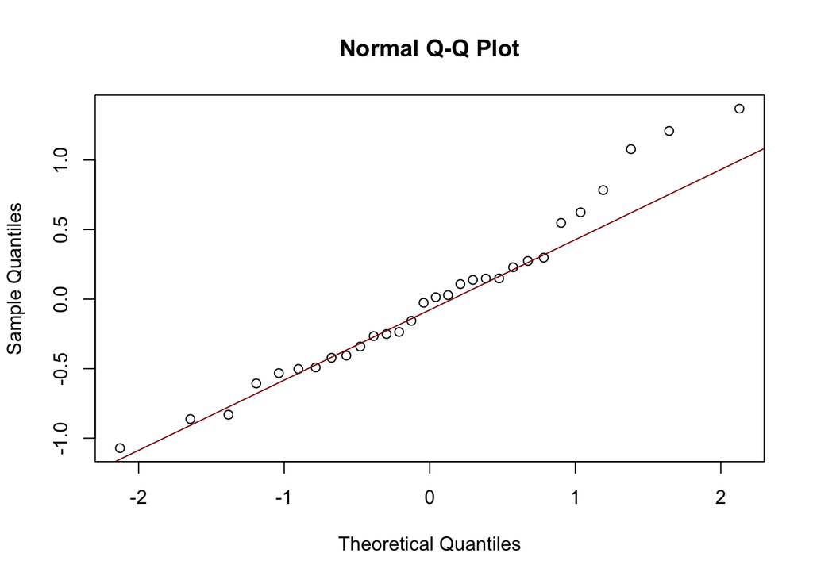

```r
# QQ-plot
qqnorm(residuos)
qqline(residuos, col = "darkred")
```

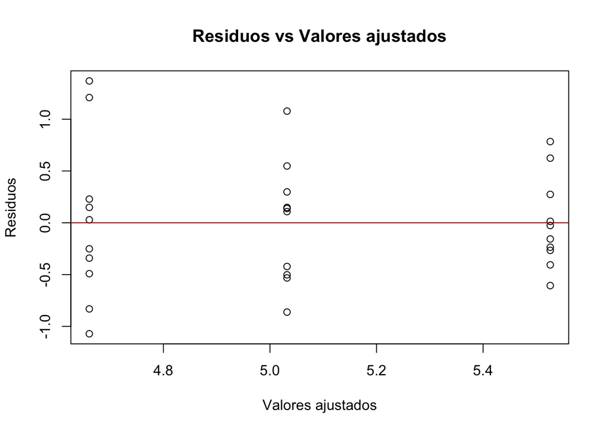

```r
# Gráfico de residuos vs valores ajustados
plot(fitted(aov_plantas), residuos,
     main = "Residuos vs Valores ajustados",
     xlab = "Valores ajustados", ylab = "Residuos")
abline(h = 0, col = "darkred")
```

```r
# Test Shapiro-Wilk
shapiro.test(residuos)
```

```
##
##  Shapiro-Wilk normality test
##
## data:  residuos
## W = 0.96607, p-value = 0.4379
```

- En el histograma observamos que los residuos siguén una distribución simétrica, del mismo modo en el QQ plot observamos que la línea se ajusta a los puntos, los residuos siguen una distribución normal.
- En la gráfica de residuos vs valores ajustados observamos que se distribuyen alrededor de 0, sin formar ningún patrón, esto indica homocedasticidad.
- Finalmente con el test de Saphiro-Whilk vemos que el p valor 0.4379 es > 0.05, no hay evidencia para rechazar normalidad.

Del análisis de los residuos concluimos que se cumplen con los principios del ANOVA: normalidad en los residuos, homogeneidad de las varianzas (homocedasticidad) e independencia de los residuos.

## Ejercicio 4

**Durante un estudio de campo, unos investigadores midieron la humedad del suelo (en porcentaje) bajo diferentes tipos de cobertura vegetal en una zona protegida. Se consideraron cuatro tipos de cubiertas: hierba baja (H1), arbustos (H2), arbolado aclarado (H3) y bosque denso (H4).**

**Para cada tipo de cobertura, se realizaron 6 muestras en puntos diferentes. Los siguientes datos son los valores de la humedad del suelo registrados:**

- H1: 28, 33, 30, 27, 31, 29

- H2: 35, 37, 36, 38, 34, 33

- H3: 40, 39, 41, 42, 40, 43

- H4: 48, 46, 47, 45, 44, 49

**Tareas a realizar:**

**1. Reformad los datos para que haya una columna con la humedad (variable numérica) y otra con el tipo de cobertura (variable factor).**

**2. Cread un gráfico ggplot2 que muestre la humedad del suelo por grupo. Interpretarlo: ¿cree que existen diferencias entre los tipos de cobertura?**

**3. Ajustad un modelo ANOVA y comentad las conclusiones. Si existen diferencias significativas, indicade qué grupos parecen más diferentes.**

**4. Valide los supuestos del modelo ANOVA mediante gráficos de residuos. Comente los resultados.**

### Apartado 1)

```r
# Reformamos los datos

# Incorporamos los datos de humedad
humedad <- c(28, 33, 30, 27, 31, 29, # H1
             35, 37, 36, 38, 34, 33, # H2
             40, 39, 41, 42, 40, 43, # H3
             48, 46, 47, 45, 44, 49) # H4

# Incorporamos los datos del tipo de cobertura,
# repitiendolos para cada valor de humedad
cobertura <- rep(c("H1", "H2", "H3", "H4"), each = 6)

# Creamos el data frame
hum_suelo <- data.frame(humedad = humedad,
                        cobertura = factor(cobertura))

# Mostramos las primeras filas
head(hum_suelo)
```

|  | humedad | cobertura |
| --- | --- | --- |
| 1 | 28 | H1 |
| 2 | 33 | H1 |
| 3 | 30 | H1 |
| 4 | 27 | H1 |
| 5 | 31 | H1 |
| 6 | 29 | H1 |

### Apartado 2)

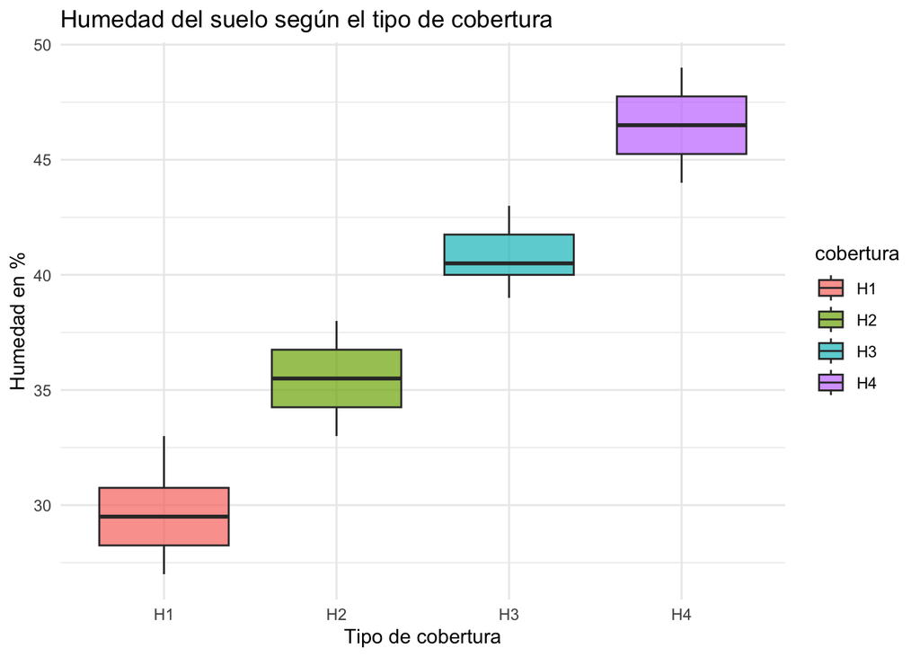

```r
# Gráfico ggplot humedad de suelo por grupo

# Cargamos la libreria
library(ggplot2)

# Realizamos el gráfico con ggplot
ggplot(hum_suelo, aes(x = cobertura, y = humedad, fill = cobertura)) +
  geom_boxplot(alpha = 0.7) +
  labs(
    x = "Tipo de cobertura",
    y = "Humedad en %",
    title = "Humedad del suelo según el tipo de cobertura"
  ) +
  theme_minimal()
```

En el gráfico observamos que según el tipo de cobertura vegetal difiere el procentaje de humedad, por tanto los suelos se pueden ordenar según su porcentaje de humedad de menor a mayor en este orden:

- Humedad: H1 < H2 < H3 < H4

Para responder a la pregunta planteada si existen diferencias entre los tipos de cobertura, parece intuirse que cada cobertura vegetal da lugar a distintos porcentajes de humedad.

### Apartado 3)

```r
# modelo ANOVA
aov_suelos <- aov(humedad ~ cobertura, data = hum_suelo)
summary(aov_suelos) # resultados
```

```
##             Df Sum Sq Mean Sq F value   Pr(>F)
## cobertura    3  935.5  311.82   90.17 8.57e-12 ***
## Residuals   20   69.2    3.46
## ---
## Signif. codes:  0 '***' 0.001 '**' 0.01 '*' 0.05 '.' 0.1 ' ' 1
```

- F value: 90.17
- p valor_ 8.57e-12

El valor de F values al ser tan alto (90.17) indica mucha variación entre los grupos, el p valor (8.57e-12) al ser < 0.05 muestra que existen diferencias significativas para la humedad en los distintos tipos de cobertura del suelo.

Realizamos el test de Tukey para estudiar que grupos presentan mas diferencias.

```r
# Test de Tukey
TukeyHSD(aov_suelos)
```

```
##   Tukey multiple comparisons of means
##     95% family-wise confidence level
##
## Fit: aov(formula = humedad ~ cobertura, data = hum_suelo)
##
## $cobertura
##            diff       lwr       upr     p adj
## H2-H1  5.833333  2.828186  8.838481 0.0001399
## H3-H1 11.166667  8.161519 14.171814 0.0000000
## H4-H1 16.833333 13.828186 19.838481 0.0000000
## H3-H2  5.333333  2.328186  8.338481 0.0003991
## H4-H2 11.000000  7.994853 14.005147 0.0000000
## H4-H3  5.666667  2.661519  8.671814 0.0001981
```

Observamos que todas las comparaciones entre los distintos tipos de cobertura son significativas pues todos los p valor entre coberturas son < 0.05, por esto deducimos que a mediada que aumenta la cobertura vegetal lo hace la humedad del suelo, a mayor cobertura mayor humedad.

El suelo con la mayor cobertura H4 es el que presenta mas humedad y el suelo H1 con menor cobertura es el que presenta menor humedad.

### Apartado 4

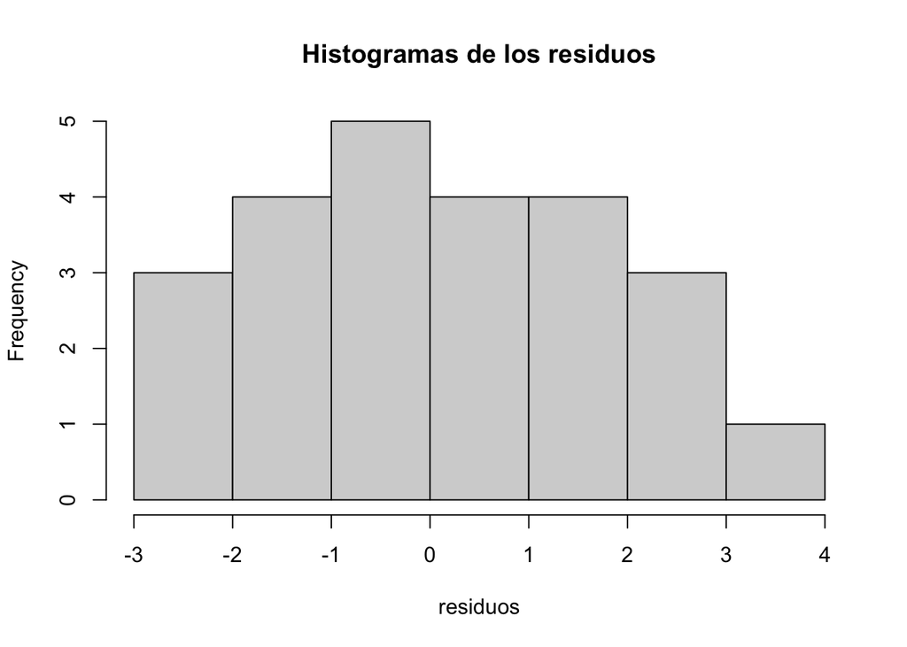

```r
# Extraemos los residuos
residuos <- residuals(aov_suelos)

# Histograma de los residuos
hist(residuos, main = "Histogramas de los residuos", xlab = "residuos")
```

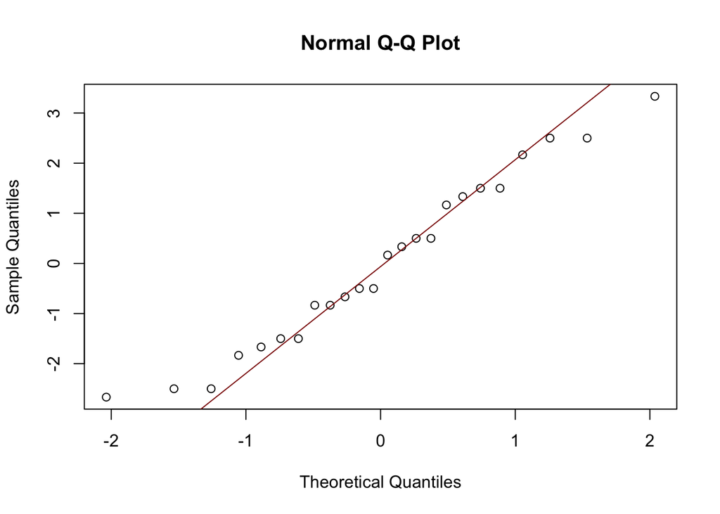

```r
## QQ plot
qqnorm(residuos)
qqline(residuos, col = "darkred")
```

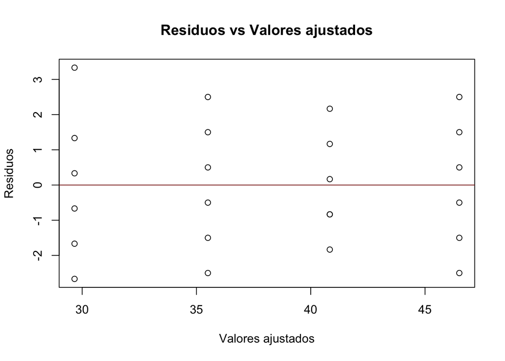

```r
# Gráfico de residuos vs valores ajustados
plot(fitted(aov_suelos), residuos,
     main = "Residuos vs Valores ajustados",
     xlab = "Valores ajustados", ylab = "Residuos")
abline(h = 0, col = "darkred")
```

```r
# Test Shapiro-Wilk
shapiro.test(residuos)
```

```
##
##  Shapiro-Wilk normality test
##
## data:  residuos
## W = 0.96235, p-value = 0.4875
```

- En el histogramo observamos que los residuos siguén una distribución simétrica, del mismo modo en el QQ plot observamos que la línea se ajusta a los puntos, los residuos siguen una distribución normal.
- En la gráfica de residuos vs valores ajustados observamos que se distribuyen alrededor de 0, sin formar ningún patrón, esto indica homocedasticidad.
- Con el test de Saphiro-Whilk vemos que el p valor 0.4875 es > 0.05, no hay evidencia para rechazar normalidad.

Del análisis de los residuos concluimos que se cumplen con los principios del ANOVA: normalidad en los residuos, homogeneidad de las varianzas (homocedasticidad) e independencia de los residuos.

# Sección 3: Aplicaciones de R

## Ejercicio 5

**Diseñar una aplicación interactiva con Shiny que permita: Cargar el archivo .csv con información sobre hábitos de salud (alimentación, ejercicio, horas de sueño…) que se genera con el siguiente código.**

```r
set.seed(123)
n <- 200 # Número de registros

df <- data.frame(
Edad = sample(18:80, n, replace = TRUE),
Género = sample(c("Hombre","Mujer"), n, replace = TRUE),
Frutos_por_día = rpois(n, lambda = 2),
Ejercicio_semanal = round(runif(n, 0, 10), 1),
Fuma = sample(c("Sí","No"), n, replace = TRUE, prob = c(0.3, 0.7)),
Dorm_media_horas = round(rnorm(n, mean = 7, sd = 1.2), 1))

# Escribe el archivo CSV
write.csv(df,"habitos_saludables.csv", row.names = FALSE)
```

**Tareas a realizar:**

**Mostrar un resumen estadístico del conjunto de datos.**

**Visualizar diferentes gráficos:**

- Un histograma de una variable cuantitativa seleccionada (p. ej.: horas de sueño).

- Un gráfico de barras para una variable categórica (p. ej.: frecuencia de actividad física).

- Un gráfico de dispersión seleccionando dos variables cuantitativas (p. ej.: horas de sueño vs IMC).

**Funcionalidades mínimas que debe tener la aplicación:**

- Uso de fileInput() para cargar el archivo.

- Selección de variables mediante selectInput().

- Visualización con plotOutput() y renderPlot().

- Mostrar el resumen con verbatimTextOutput() y renderPrint().

*Nota: puede realizar capturas de pantalla para explicar los pasos que vaya desarrollando para crear la aplicación.*

```r
# Creamos la aplicación Shiny

# Cargamos las librerias
library(shiny)

# Definimos la interfaz de la aplicación shiny
ui <- fluidPage(
  titlePanel("Conjunto de datos de pacientes"),
  sidebarLayout(
    sidebarPanel(
      # Cargamos el archivo
      fileInput("file", "especifica el conjunto de datos a mostrar"),
      # Selectores de las variables x e y
      uiOutput("var_hist"),
      uiOutput("var_bar"),
      uiOutput("x_var"),
      uiOutput("y_var")
    ),

    mainPanel(
      h4("Resumen estadístico del conjunto de datos"),
      verbatimTextOutput("resumen"),
      # Gráficos
      h4("Histograma de variable cuantitativa"),
      plotOutput("histograma"),
      h4("Gráfico de barras para variable categórica"),
      plotOutput("barras"),
      h4("Gráfico de dispersión entre dos variables cuantitativas"),
      plotOutput("dispersion")
    )
  )
)

# Definimos el servidor de la aplicación
server <- function(input, output) {
  # Cargamos el conjunto de datos
  dataset <- reactive({
    req(input$file)
    read.csv(input$file$datapath)
  })

  # Genera selectInput para cada tipo de gráfico
  output$var_hist <- renderUI({
    req(dataset())
    numeric_vars <- names(dataset())[sapply(dataset(), is.numeric)]
    selectInput("hist_var", "Variable para histograma:", choices = numeric_vars)
  })

  output$var_bar <- renderUI({
    req(dataset())
    cat_vars <- names(dataset())[sapply(dataset(), is.factor) | sapply(dataset(), is.character)]
    selectInput("bar_var", "Variable para gráfico de barras:", choices = cat_vars)
  })

  output$x_var <- renderUI({
    req(dataset())
    numeric_vars <- names(dataset())[sapply(dataset(), is.numeric)]
    selectInput("xvar", "Variable X (cuantitativa):", choices = numeric_vars)
  })

  output$y_var <- renderUI({
    req(dataset())
    numeric_vars <- names(dataset())[sapply(dataset(), is.numeric)]
    selectInput("yvar", "Variable Y (cuantitativa):", choices = numeric_vars)
  })


  # Histograma
  output$histograma <- renderPlot({
    req(input$hist_var)
    hist(dataset()[[input$hist_var]],
         col = "skyblue",
         main = paste("Histograma de", input$hist_var),
         xlab = input$hist_var)
  })

  # Gráfico de barras
  output$barras <- renderPlot({
    req(input$bar_var)
    var <- as.factor(dataset()[[input$bar_var]])
    barplot(table(var),
            col = "lightcoral",
            main = paste("Frecuencia de", input$bar_var),
            xlab = input$bar_var,
            ylab = "Frecuencia")
  })

  # Gráfico de dispersión
  output$dispersion <- renderPlot({
    req(input$xvar, input$yvar)
    plot(dataset()[[input$xvar]], dataset()[[input$yvar]],
         col = "darkgreen",
         pch = 19,
         xlab = input$xvar,
         ylab = input$yvar,
         main = paste("Dispersión:", input$yvar, "vs", input$xvar))
  })

  output$resumen <- renderPrint({
    req(dataset())
    summary(dataset())
  })

}
# Ejecutamos la aplicacion shiny
shinyApp(ui, server)
```

[interactive chart not shown]

# Referencias

Venables, W. N., & Ripley, B. D. (2021). Pima.tr (version 7.3). https://rdrr.io/cran/MASS/man/Pima.tr.html

R Core Team. (2021). mtcars (version 4.1.0). https://stat.ethz.ch/R-manual/R-devel/library/datasets/html/mtcars.html

# Anexo

**Imágenes de los resultados de la aplicación shiny**

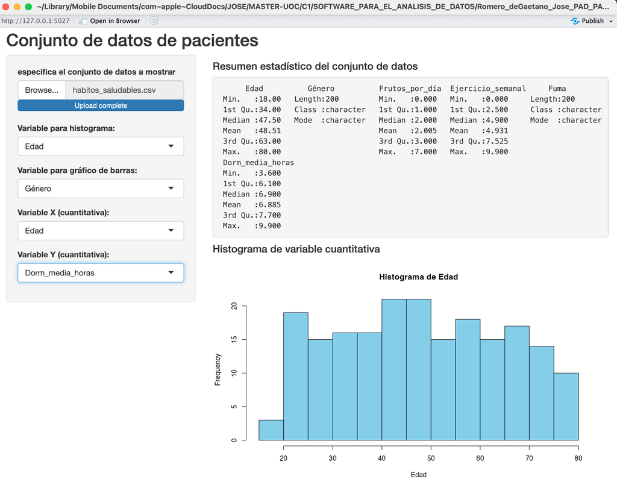

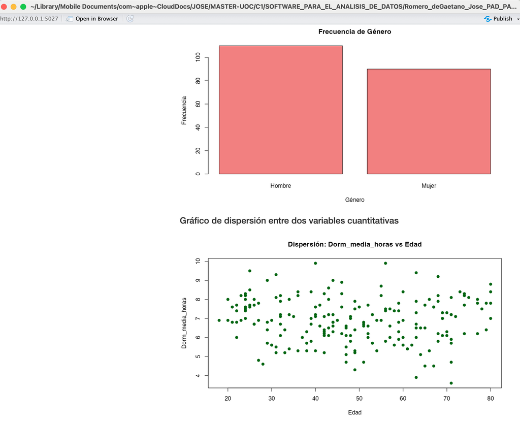